# Day 7: gghalves

The package is available from CRAN and can be downloaded with

```r
install.packages("gghalves")
```

we will be working with Santa’s `elf` dataset. The data includes 50 observations for 3 elves (150 observations total) taken monthly describing the elfly capacities. Units have been removed due to being classified.

```r
library(skimr)
skim(elf)
```

(#tab:unnamed-chunk-4)Data summary

| Name | elf |
| --- | --- |
| Number of rows | 150 |
| Number of columns | 5 |
| _______________________ |  |
| Column type frequency: |  |
| factor | 1 |
| numeric | 4 |
| ________________________ |  |
| Group variables | None |

**Variable type: factor**

| skim_variable | n_missing | complete_rate | ordered | n_unique | top_counts |
| --- | --- | --- | --- | --- | --- |
| Elf | 0 | 1 | FALSE | 3 | Bud: 50, Twi: 50, Hol: 50 |

**Variable type: numeric**

| skim_variable | n_missing | complete_rate | mean | sd | p0 | p25 | p50 | p75 | p100 | hist |
| --- | --- | --- | --- | --- | --- | --- | --- | --- | --- | --- |
| Toy Making Intensity | 0 | 1 | 5.84 | 0.83 | 4.3 | 5.1 | 5.80 | 6.4 | 7.9 | ▆▇▇▅▂ |
| Sugar Consumption | 0 | 1 | 3.06 | 0.44 | 2.0 | 2.8 | 3.00 | 3.3 | 4.4 | ▁▆▇▂▁ |
| Jolliness | 0 | 1 | 3.76 | 1.77 | 1.0 | 1.6 | 4.35 | 5.1 | 6.9 | ▇▁▆▇▂ |
| Reindeer Training | 0 | 1 | 1.20 | 0.76 | 0.1 | 0.3 | 1.30 | 1.8 | 2.5 | ▇▁▇▅▃ |

since we have a categorical variable (`elf`) and a couple of continuous variables we could use **ggplot2** to visualize the distributions. Let us take a first look at the TMI (Toy Making Intensity) variable. We can create a boxplot for each elf by using `geom_boxplot()`

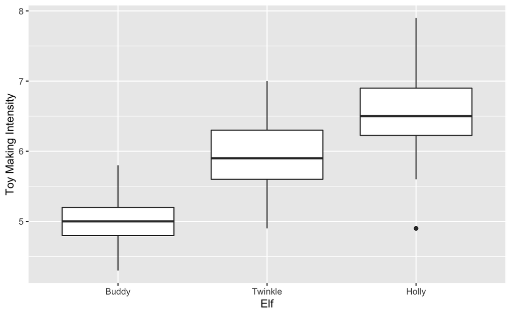

```r
library(ggplot2)
ggplot(elf, aes(Elf, `Toy Making Intensity`)) +
  geom_boxplot()
```

But we can’t see the individual points. you could do a second plot with `geom_dotplot()`

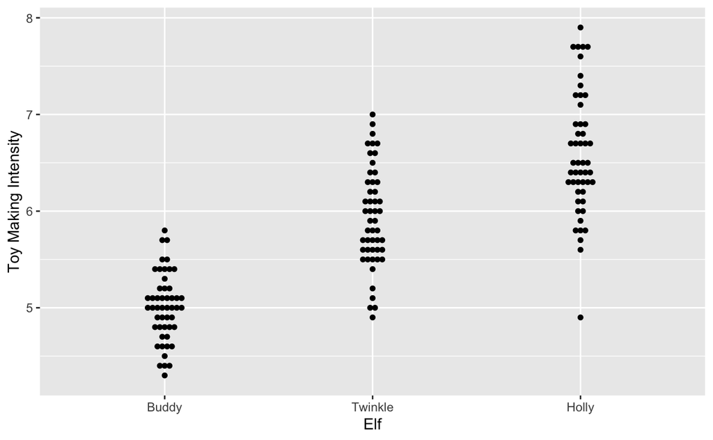

```r
ggplot(elf, aes(Elf, `Toy Making Intensity`)) +
  geom_dotplot(binaxis = "y", stackdir = "center", binwidth = 0.05)
```

But now we have two separate charts trying to show the same data. This is where **gghalves** comes in! **gghalves** allows you to split many of the aggregation geoms in half. It is easier to show with an example. We have the data from before and we want to showcase a boxplot and a dotplot at the same time.

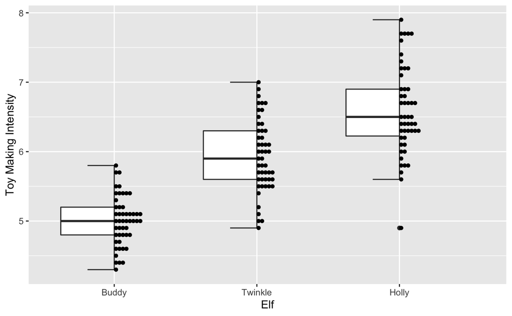

```r
library(gghalves)
ggplot(elf, aes(Elf, `Toy Making Intensity`)) +
  geom_half_boxplot() +
  geom_half_dotplot(binwidth = 0.05)
```

by using `geom_half_boxplot()` and `geom_half_dotplot()` we we able to elegently combine 2 plot types.

The geoms respect general **ggplot2** elements so things like color

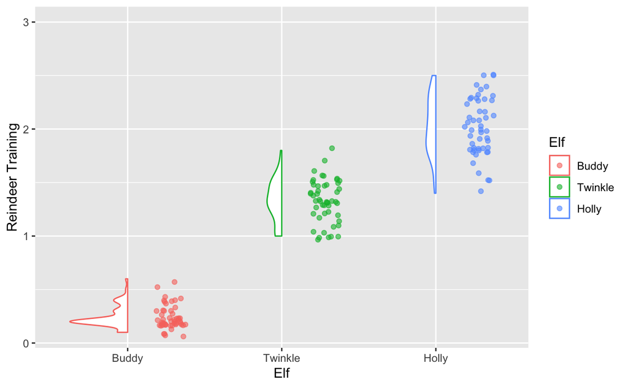

```r
ggplot(elf, aes(Elf, `Reindeer Training`, color = Elf)) +
  geom_half_violin() +
  geom_half_point(alpha = 0.6)
```

and factors

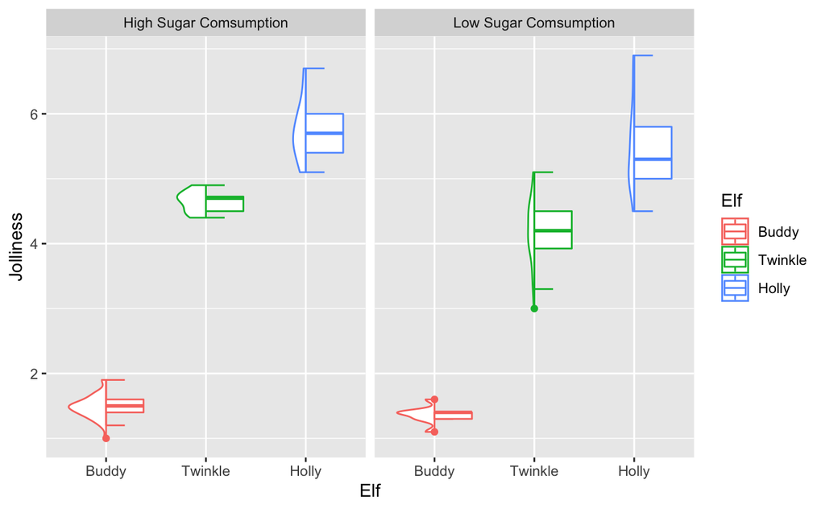

```r
ggplot(elf, aes(Elf, Jolliness, color = Elf)) +
  geom_half_violin() +
  geom_half_boxplot(side = "r") +
  facet_wrap(~ factor(`Sugar Consumption` > mean(`Sugar Consumption`),
                      c(TRUE, FALSE),
                      c("High Sugar Comsumption", "Low Sugar Comsumption")))
```

**Creating `elf` dataset**

```r
library(tidyverse)
set.seed(1234)

elf <- iris %>%
  rename(Elf = Species,
         `Sugar Consumption` = Sepal.Width,
         `Toy Making Intensity` = Sepal.Length,
         `Jolliness` = Petal.Length,
         `Reindeer Training` = Petal.Width) %>%
  mutate(Elf = factor(as.numeric(Elf), labels = c("Buddy", "Twinkle", "Holly"))) %>%
  mutate_if(is.numeric, jitter)
```